# Koronašit v číslech

Medvídek Pů

June 23, 2020

## Open edX

Po zavření škol nastal v edexu největší nárůst registrací i zápisů ever: k 10. 3. registujeme 682 nových uživatelů a 922 nových registrací. To je ale do značné míry dáno probíhající propagační kampaní - zdá se ale, že účinnost kampaně se po zavření škol výrazně zvýšila (probíhala od začátku února).

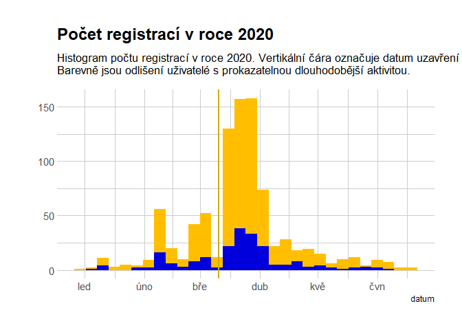

Podle dostupných metrik se ale nezdá, že by uživatelé v tomto období byli “trvalejší”, naopak průměrná úmrtnost je o něco vyšší (přibližně o deset procentních bodů).

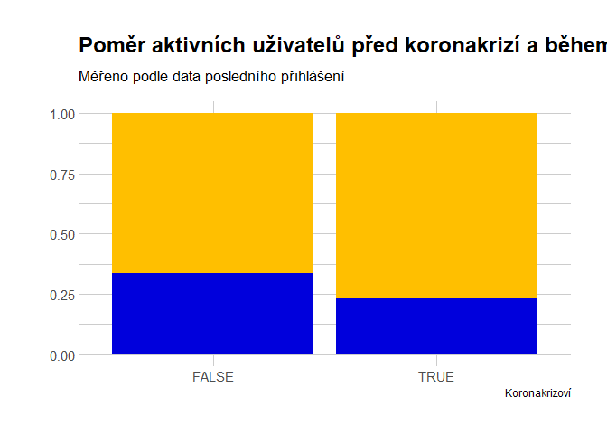

## ELF

Málokdo vytvářel kvůli distanční výuce nové kurzy. Chceme zjišťovat, co se dělo v těch již existujících.

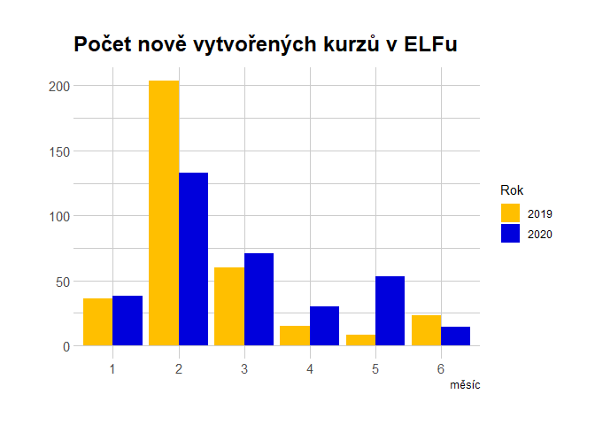

## Medial

Od začátku koronakrize přibylo v Medialu 704 videí. Tempo nárůstu není výrazně vyšší než v minulých letech, to je dáno hlavně tím, ženevznikaly záznamy v učebnách. Výrazně více tedy vzniklo záznamů z jiných zdrojů.

Od začátku dubna, kdy jsme začali evidovat počty videí z TS Relay, jich do Medialu doputovalo 339.

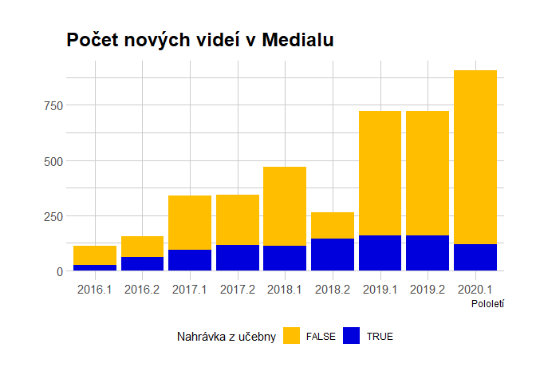

Počet uživatelů, kteří od začátku roku nahráli do Medialu jakýkoliv obsah, opět šokantně nepřevyšuje podzvolný dlouhodobý nárůst. Během koronakrize nicméně do Medialu vložilo obsah 113 uživatelů, kteří jej dříve nikdy nevyužili.

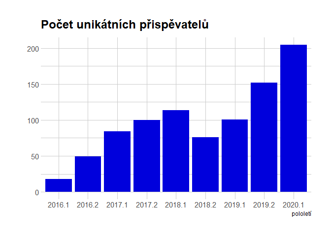

Oproti předchozím zaznamenaným stavům výrazně narostl celkový počet zhlédnutí videí:

```
## # A tibble: 3 x 2
##   datum       součet
##   <chr>        <dbl>
## 1 září 2019    13281
## 2 únor 2020    18687
## 3 červen 2020  29919
```

Jemně se zvedl průměrný počet zhlédnutí: 5.2021152 v září 2019, 5.7042125 letos v únoru a 7.418547 aktuálně.

Videa vložená v době online výuky mají obecně vyšší počty zhlédnutí:

```
## # A tibble: 2 x 3
##   corona prumer median
##   <lgl>   <dbl>  <dbl>
## 1 FALSE    6.83    1
## 2 TRUE    10.2     1.5
```

A obecně počty zhlédnutí v porovnáním se stavem ze září narůstají:

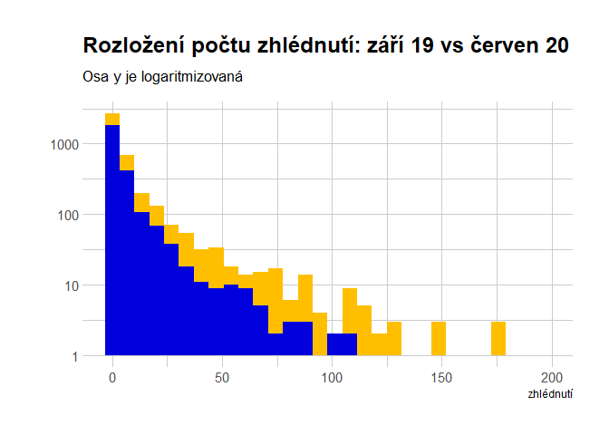